# Lab #5

Braedon Giblin

1. Are there some days of the week where more accidents happen than the others (see FARS manual, use variable DAY_WEEK)?

   Answer:

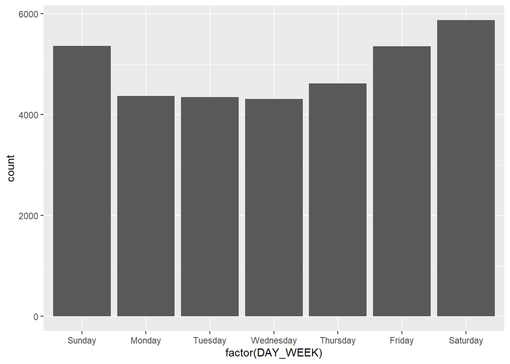

   ```r
   acc %>%
     ggplot(aes(x=factor(DAY_WEEK))) + geom_bar() + scale_x_discrete(breaks = 1:7, labels=c("Sunday", "Monday", "Tuesday", "Wednesday", 'Thursday', "Friday", "Saturday"))
   ```

   There appears to be many more traffic accidents over the weekends, particularly Friday and Saturday. This is probably due to more people traveling these days, and possibly drunk driving incicdents as well.
2. Create a data frame containing the persons who are fatally hurt in the accidents (look up variable INJ_SEV)

   Answer:

   ```r
   fatal <- person %>%
     filter(INJ_SEV == 4)

   str(fatal)
   ```

   ```
   ## 'data.frame':    37133 obs. of  68 variables:
   ##  $ STATE     : int  1 1 1 1 1 1 1 1 1 1 ...
   ##  $ ST_CASE   : int  10001 10002 10003 10004 10005 10006 10007 10008 10009 10011 ...
   ##  $ VE_FORMS  : int  1 1 3 1 1 2 2 1 1 2 ...
   ##  $ VEH_NO    : int  1 1 2 1 1 1 1 1 1 1 ...
   ##  $ PER_NO    : int  1 1 1 1 1 1 1 1 1 1 ...
   ##  $ STR_VEH   : int  0 0 0 0 0 0 0 0 0 0 ...
   ##  $ COUNTY    : int  73 89 101 73 13 49 73 3 87 87 ...
   ##  $ DAY       : int  19 14 31 1 1 6 11 11 11 15 ...
   ##  $ MONTH     : int  2 2 1 1 1 1 1 1 1 1 ...
   ##  $ HOUR      : int  23 14 20 16 20 18 17 16 14 4 ...
   ##  $ MINUTE    : int  35 59 31 55 0 40 57 50 30 35 ...
   ##  $ RUR_URB   : int  2 2 2 2 1 1 2 1 1 2 ...
   ##  $ FUNC_SYS  : int  1 1 1 4 1 1 1 1 1 1 ...
   ##  $ HARM_EV   : int  38 1 12 30 35 34 12 35 21 12 ...
   ```

   [output cut: 54 more lines]

3. Create a data frame containing the most dangerous vehicle make in each state. The number of persons fatally hit in the vehicle make is used to assess the (non-)safety of a make. Make sure to handle the missing values appropriately. (look up variable MAKE)

   Answer:

   ```r
   m <- vehicle %>%
     select(ST_CASE, MAKE)

   most_dangerous <- acc %>%
     inner_join(m, by="ST_CASE") %>%
     group_by(STATE, MAKE) %>%
     summarise(fatal = sum(FATALS))  %>%
     filter(fatal == max(fatal)) %>%
     ungroup(STATE) %>%
     arrange(STATE)
   head(most_dangerous)
   ```

   ```
   ## # A tibble: 6 x 3
   ##   STATE  MAKE fatal
   ##   <int> <int> <int>
   ## 1     1    20   233
   ## 2     2    12    18
   ## 3     4    20   202
   ## 4     5    20   130
   ## 5     6    49   786
   ## 6     8    12   136
   ```

4. Create a map, and label each state with the most dangerous vehicle. Discuss the definition of the most dangerous vehicle, and what you find from the map.

   Answer:

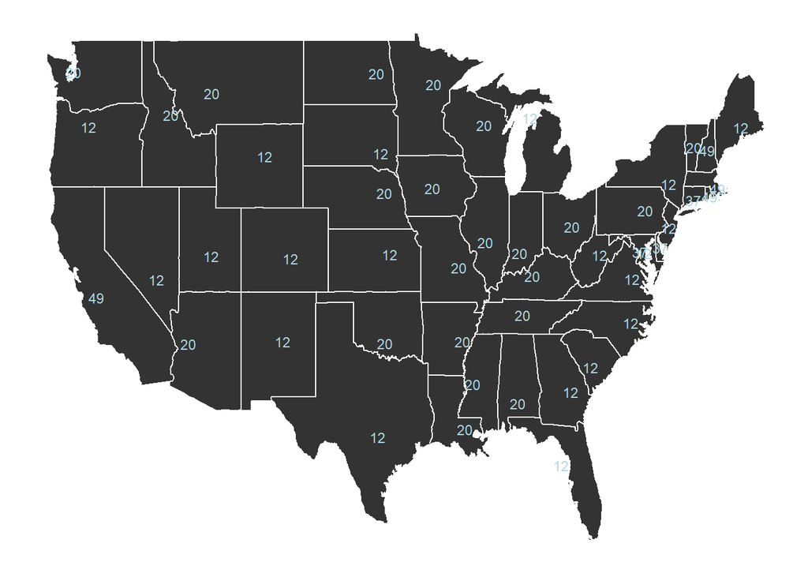

   ```r
   states <- map_data('state')

   states <- states %>%
     mutate(region = toupper(region))

   suppressWarnings(glcs <- readxl::read_xlsx("GLCs.xlsx") %>%
     rename(region = `State Name`,
            STATE = `State Code`) %>%
     mutate(STATE = as.numeric(STATE)))


   m <- glcs %>%
     inner_join(most_dangerous, by='STATE') %>%
     inner_join(states, by="region") %>%
     group_by(region) %>%
     summarise(long = mean(long),
               lat = mean(lat),
               MAKE = mean(MAKE))

   ggplot(states, aes(x=long, y=lat)) + geom_polygon(aes(group=group), color="white") +
     theme_map() +
     geom_text(aes(label = MAKE), data = m , size = 3, hjust =0.5, color = "lightblue")
   ```

   Most states seem to have Make 12 (Ford) and Make 20 (Chevrolet) as the most dangerous. This is likely because these are the most popular car brands in a America. Our current operational definition of vehicle safety fails to take in to account how many people drive each make.
5. Join the accident and person table (work out which variable(s) to use)

   Answer:

   ```r
   joined = acc %>%
     inner_join(person, by='ST_CASE')

   head(joined)
   ```

   ```
   ##   STATE.x ST_CASE VE_TOTAL VE_FORMS.x PVH_INVL PEDS PERNOTMVIT PERMVIT PERSONS
   ## 1       1   10001        1          1        0    0          0       1       1
   ## 2       1   10002        1          1        0    0          0       1       1
   ## 3       1   10003        3          3        0    0          0       3       3
   ## 4       1   10003        3          3        0    0          0       3       3
   ## 5       1   10003        3          3        0    0          0       3       3
   ## 6       1   10004        1          1        0    0          0       1       1
   ##   COUNTY.x CITY DAY.x MONTH.x YEAR DAY_WEEK HOUR.x MINUTE.x NHS RUR_URB.x
   ## 1       73  330    19       2 2017        1     23       35   1         2
   ## 2       89 1730    14       2 2017        3     14       59   1         2
   ## 3      101 2130    31       1 2017        3     20       31   1         2
   ## 4      101 2130    31       1 2017        3     20       31   1         2
   ## 5      101 2130    31       1 2017        3     20       31   1         2
   ## 6       73  350     1       1 2017        1     16       55   0         2
   ##   FUNC_SYS.x RD_OWNER ROUTE        TWAY_ID       TWAY_ID2 MILEPT LATITUDE
   ```

   [output cut: 83 more lines]

6. Tally the number of accidents by day of the week (DAY_WEEK), hour of the day (HOUR) and gender (SEX). Visualize the results and explain what you find.

   Answer:

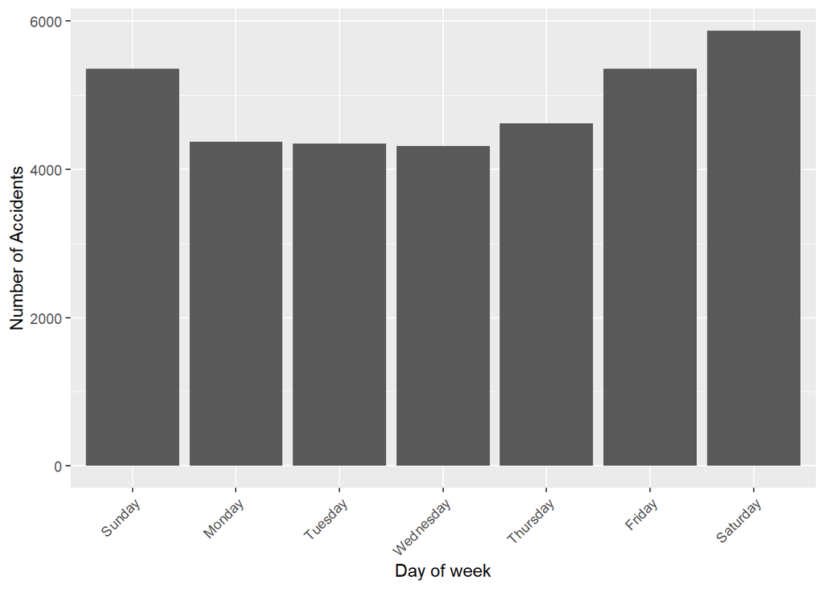

   ```r
   #Day of week
   acc %>%
     count(DAY_WEEK) %>%
     mutate(`Day of week` = factor(DAY_WEEK, levels=1:7,
                     labels=c("Sunday", "Monday", "Tuesday", "Wednesday",
                              "Thursday", "Friday", "Saturday"))) %>%
     rename(`Number of Accidents` = n) %>%
     ggplot(aes(x=`Day of week`, y=`Number of Accidents`)) + geom_bar(stat="identity")  + theme(axis.text.x = element_text(angle = 45, hjust = 1))
   ```

   Crashes seem to be more numerous on the weekend and towards the end of the week.

   Answer:

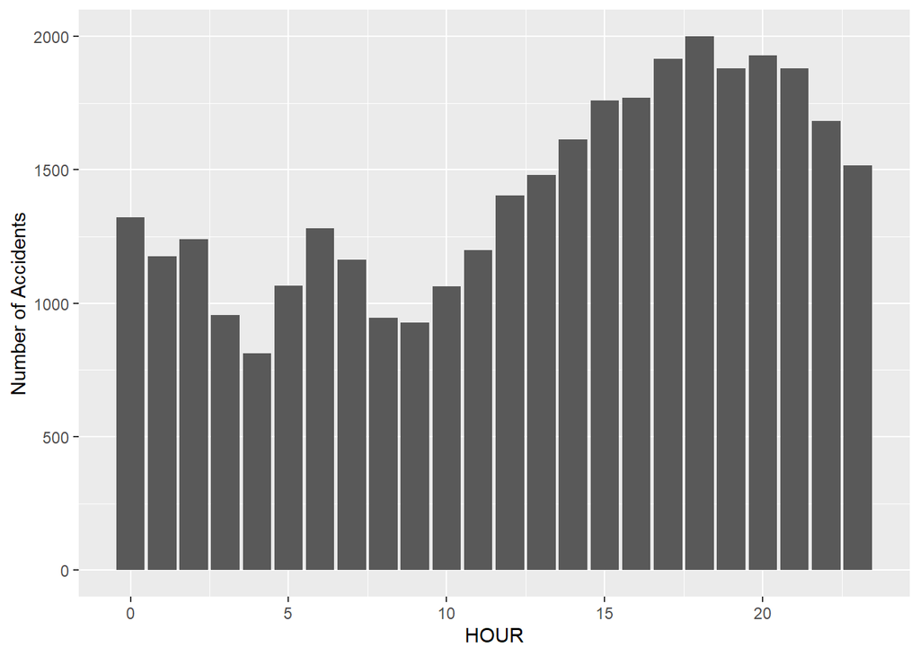

   ```r
   #Hour
   acc %>%
     count(HOUR) %>%
     rename(`Number of Accidents` = n) %>%
     filter(HOUR < 25) %>% # Filter out "Unknown Hour"
     ggplot(aes(x=`HOUR`, y=`Number of Accidents`)) + geom_bar(stat="identity")
   ```

   Most accidents seem to occur in the afternoon through early the evening. Crashes are worst at around 5:00 pm, likely when many people are commuting to work, and decline as the night goes on.

   Answer:

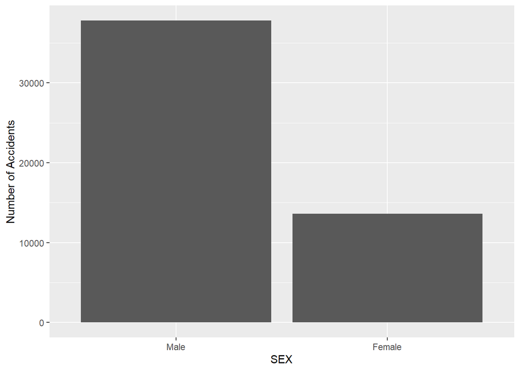

   ```r
   #Gender
   joined %>%
     filter(SEAT_POS == 11 & SEX < 3) %>% # We only care about the driver
     count(SEX) %>%
     mutate(SEX = factor(SEX, levels=1:2,
                     labels=c("Male", "Female"))) %>%
     rename(`Number of Accidents` = n) %>%
     ggplot(aes(x=`SEX`, y=`Number of Accidents`)) + geom_bar(stat="identity")
   ```

   Males seem to get in significantly more accidents than females.
7. Now plot a choropleth map of the number of deaths on a county level. Also explain what you find.

   Answer:

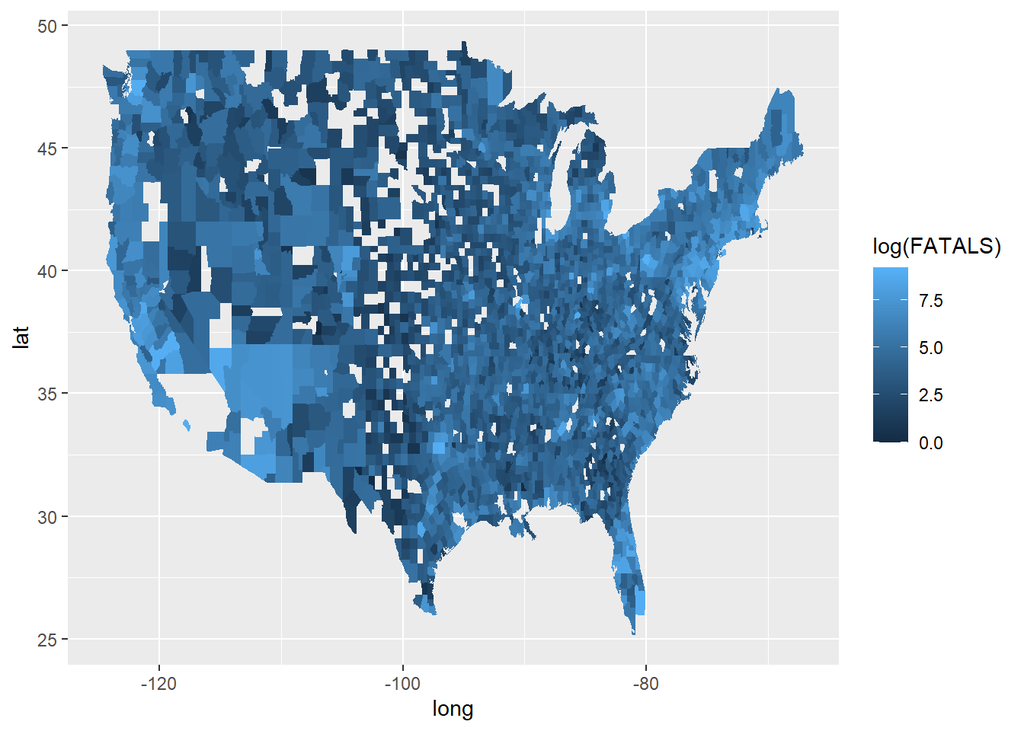

   ```r
   county <- map_data('county')

   county <- county %>%
     mutate(region = toupper(region),
            subregion = toupper(subregion))

   suppressWarnings(
   glcs <- readxl::read_xlsx("GLCs.xlsx") %>%
     rename(region = `State Name`,
            subregion = `County Name`,
            STATE = `State Code`,
            COUNTY = `County Code`) %>%
     mutate(STATE = as.numeric(STATE),
            COUNTY = as.numeric(COUNTY))
   )

   glcs %>%
     inner_join(acc, by=c("STATE", "COUNTY")) %>%
     select(region, subregion, FATALS) %>%
     group_by(region, subregion) %>%
     summarise(FATALS = sum(FATALS)) %>%
     ungroup(region) %>%
     left_join(county, by=c("region", "subregion")) %>%
     filter(FATALS < 10000) %>%
     ggplot(aes(x=long, y=lat, fill=log(FATALS))) + geom_polygon(aes(group=group))
   ```

   ```r
     #ggplot(states, aes(x=long, y=lat)) + geom_polygon(aes(group=group), color="white") +
     #theme_map() +
     #geom_text(aes(label = MAKE), data = m , size = 3, hjust =0.5, color = "lightblue")
   ```

   City areas seem to have the highest amount of traffic accidents. Notably, LA and New York City have high number of crashes. I elected to use a log scale for the color to more easily account for the wide variances in fatalities.
8. Is summer or winter more dangerous? Does this depend on states? Explore and explain.

   Answer:

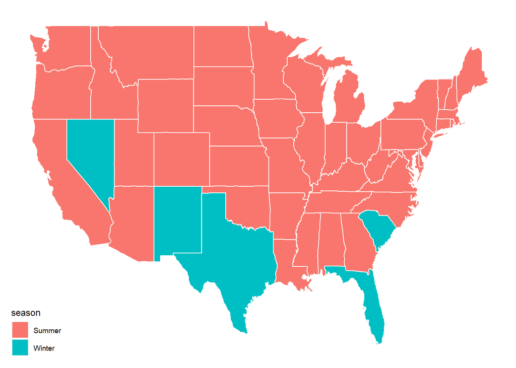

   ```r
   state <- map_data('state') %>%
     mutate(region = toupper(region),
            subregion = toupper(subregion))

   suppressWarnings(
   glcs <- readxl::read_xlsx("GLCs.xlsx") %>%
     rename(region = `State Name`,
            subregion = `County Name`,
            STATE = `State Code`,
            COUNTY = `County Code`) %>%
     mutate(STATE = as.numeric(STATE),
            COUNTY = as.numeric(COUNTY))
   )

   seasons <- acc %>%
     mutate(season = factor(ifelse(MONTH < 4 | MONTH > 9, 'Winter', 'Summer')))

   seasons <- seasons %>%
     group_by(STATE, season) %>%
     summarise(fatal = sum(FATALS))  %>%
     filter(fatal == max(fatal)) %>%
     ungroup(STATE) %>%
     arrange(STATE)
   m <- glcs %>%
     group_by(region) %>%
     summarise(STATE = mean(STATE)) %>%
     right_join(seasons, by=c('STATE')) %>%
     select(region, season) %>%
     right_join(state, by="region") #%>%


   ggplot(m, aes(x=long, y=lat, fill=season)) + geom_polygon(aes(group=group), color="white") +
     theme_map()
   ```

   I defined “More dangerous” as the number of fatalities. I added a new column, season, that reflected summer and winter months. I then classified each state as being more dangerous in one season or the other, and then drew a map. Most of the US seems to have more accidents in the summer. This is likely because more people drive. The exceptions are generally warm climate states where people may have less experience driving in winter conditions, so if it snows there are many more accidents.